# Constraining Cosmological Parameters Using Type Ia Supernovae

*A 488 Computational Astrophysics Project by Tyler Barna<sup>1</sup>, Rachel Campo<sup>1</sup>, Neeharika Thuravil<sup>1</sup>, and Ilya Venediktov<sup>1</sup>*

<sup>1</sup>Department of Physics and Astronomy, Rutgers, the State University of New Jersey, New Brunswick

## Dependencies

Like any organized python notebook, we start by importing the relevant modules and choosing convenient aliases for oft used packages

```python
import numpy as np
import sympy as sp
import astropy as ap
import astropy.units as u
import scipy as sci
import corner
import emcee as mc
import matplotlib as mpl
import matplotlib.pyplot as plt


from sympy import Float as f
from sympy import limit as lim

from astropy import constants as const
from astropy.cosmology import WMAP9 as cosmo
from astropy.cosmology import LambdaCDM
from astropy.cosmology import wCDM

from scipy import linalg as la
from scipy import optimize
from scipy import integrate
from scipy import stats

from emcee import EnsembleSampler as es

from matplotlib import cm

mpl.rcParams['mathtext.fontset'] = 'stix'
mpl.rcParams['font.family'] = 'serif'
mpl.rcParams['font.sans-serif'] = 'stix'
mpl.rcParams['text.usetex'] = True

np.set_printoptions(threshold=np.inf)
%matplotlib inline
```

## Importing Data

Here, we import the Pantheon Supernova Parameters from Scolnic et al. , which can be found [here](https://archive.stsci.edu/prepds/ps1cosmo/scolnic_datatable.html) in both an interactive table and the text file we used. For convenience, a function is defined to provide an array of the data given the desired column from the data set. While the two dimensional array of the entire data set is not used in this notebook, it is useful for some of the sub-analyses conducted by the individual group members and is included in this notebook as a result.

```python
def dataArray(data):
    ## creates an array of data given the column number (removes first term since the first row of the data file is the legend)

    ## columns(0-5): name(0), zcmb(1), zhel(2) dz(3), mb(4), dmb(5)
    ### Name: Target ID
    ### ZCMB: Redshift calculated in the frame of CMB
    ### ZHEL: Redshift calculated in the frame of the sun
    ### dZ: Error in spectroscopic redshifts (Note: they're technically not zero but they're so small they're basically negligible)
    ### MB: apparent magnitude
    ### dMB: error in apparent magnitude

    f = open('data.txt')
    array = []
    array = [x.split(' ')[data] for x in f.readlines()]
    array.pop(0)
    f.close()
    if str(data) == '0':
        return np.array(array)
    else:
        return np.array(array).astype(float)


## Creates 2d numpy array of all the data
fullDataArray = np.array([dataArray(0), dataArray(1), dataArray(2), dataArray(3), dataArray(4), dataArray(5)])
fullDataArray = np.transpose(fullDataArray)
```

Now that we have the data imported, we can generate some plots to get an idea of what the data looks like. Looking at the median line as well as the histogram of the data shows that there is a fairly noticeable bias towards low redshift targets in this data set. With this bias comes implications for the constraining of parameters, a topic that will be explored further in a sub-analysis. It is also worth noting that, while the error bars for the apparent magnitude are readily visible, the error bars for redshift are essentially nonexistent at all values of redshift. Because of this, the redshift error is largely ignored in our analysis.

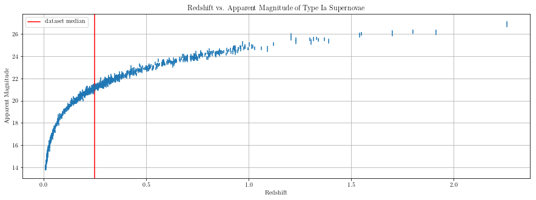

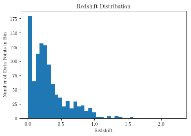

```python
small_plot = plt.figure(figsize=(6,3));
med_plot = plt.figure(figsize=(12,4));
large_plot = plt.figure(figsize=(15,5));

## redshift vs apparent magnitude ##
plt.figure(figsize=(15,5))
plt.title('Redshift vs. Apparent Magnitude of Type Ia Supernovae')
plt.errorbar(dataArray(2),dataArray(4),yerr=dataArray(5),xerr= dataArray(3),fmt=',')
plt.axvline(np.median(dataArray(2)),label='dataset median',c='r')
plt.grid(b=1)
plt.xlabel('Redshift')
plt.ylabel('Apparent Magnitude')
plt.legend()
plt.savefig('DataRedshiftAppMag')
plt.show();
plt.clf()

## Histogram of redshift distribution ##
plt.figure();
plt.title('Redshift Distribution')
plt.hist(dataArray(2),bins='auto')
plt.xlabel('Redshift')
plt.ylabel('Number of Data Points in Bin')
plt.savefig('redshiftDistHistogram')
plt.show()
plt.clf()
```

## Best Fit Analysis

Now that we have an idea of what the data is like, we will define functions for calculating the luminosity distance and distance modulus, respectively, which are defined for the two main models we are constraining the parameters of:

- ΛCDM: A flat cosmological model that shows the current state of our universe today with the accompanying cosmological parameters. According to Sclonic et al. (2018), this means that our universe is "flat, accelerating, and primarily composed of baryons, dark matter, and dark energy." There is the radiation density, but we exclude it because we do not use it in this analysis. The cosmological pararmeters we are attemtping to constrain for this model are Ω<sub>M</sub>, the matter density parameter, and Ω<sub>Λ</sub>, the dark energy density parameter.
- ωCDM: A flat cosmological model that describes a universe where the dark energy is dictated by how the matter density changes. The cosmological parameters we are attempting to constraing for this model are Ω<sub>M</sub>, again the matter density parameter, and ω, which in this model is a constant equation of state parameter for dark energy equivalent to P/ρ, where P is the pressure and ρ is the energy density of dark energy.

Note: As one can see, the Hubble constant is set to a value of 70 km/s Mpc. While this is indeed an experimentally determined value that would ideally be constrained as part of our model, it is difficult to do so given our method of analysis and therefore it remains as the experimentally accepted approximate value for our purposes.

```python
def dL_astropy_lambda( ΩM, ΩΛ, z, w ):
    ## Calculates the distance (dL) using astropy and returns the values as an array in units of pc
    dL = LambdaCDM(H0=70, Om0=ΩM, Ode0=ΩΛ)
    return dL.luminosity_distance(z).to_value(u.pc)

def μ_model_lambda(ΩM, ΩΛ, z, w ):
    ## (Note: it's μ (written as '\mu' then tab), not u ) Finds a model distance in using redshift
    ## using redshift and cosmologial parameters.
    μ = 5 * np.log10(dL_astropy_lambda(ΩM, ΩΛ, z, w)/10)
    return μ

def dL_astropy_omega( ΩM, ΩΛ, z, w ):
    ## Similar function to dL_astropy_lambda, only the astropy model is changed to the wCDM model
    dL = wCDM(H0=70, Om0=ΩM, Ode0=ΩΛ,w0=w)
    return dL.luminosity_distance(z).to_value(u.pc)

def μ_model_omega( ΩM, ΩΛ, z, w ):
    ## Operates the same as μ_model_lambda but makes a call to dL_astropy_omega instead
    μ = 5 * np.log10(dL_astropy_omega( ΩM, ΩΛ, z, w )/10)
    return μ
```

We now arrive at the point where we define the method in which we constrain the parameters mentioned above. In order to constrain the parameters, we define a penalty function, known as $\chi^{2}$ or the "chi square" function, that, in this case, takes the form

$ \chi^2(m,d) = \sum_{i=1}^{n} \left( \frac{m_{i}-d_{i}}{\sigma_{i}} \right)^2 $

where *m* is some function with parameters yet to be determined, *d* is an experimentally determined set of values for that function, *$\sigma$* is the error of those experimentally determined values, and *n* is the number of data points in *d*. Minimizing $\chi^{2}$ by varying the values of the parameters of *m* allows one to determine the values of these parameters so they best fit the experimental data. We accomplish this using the scipy library's $\texttt{optimize.fmin}$ function, which returns the best fit for the parameters as well as the number of iterations it went through to determine the current value and the number of times the function was evaluated. In this case, the output of the function is supressed so these attributes aren't printed every time the function is called, which will be convenient later.

```python
def ΛCDM_Χ(params):
    M = params[0]
    ΩM = params[1]
    ΩΛ = params[2]
    rs = dataArray(2)
    m_data = dataArray(4)
    dm = dataArray(5)
    #print(M)
    w = -1
    #print(M_data.shape)
    Χ_squared = np.sum((M + μ_model_lambda(ΩM, ΩΛ, rs, w ) - m_data)**2 / dm**2)
    #print(Χ_squared)
    return Χ_squared


def ωCDM_Χ(params):
    M = params[0]
    ΩM = params[1]
    ΩΛ = 1 - ΩM
    w = params[2]
    rs = dataArray(2)
    m_data = dataArray(4)
    dm = dataArray(5)
    Χ_squared = np.sum((M + μ_model_omega(ΩM, ΩΛ, rs, w ) - m_data)**2 / dm**2)
    return Χ_squared

def opt_lambda(params):
    #M_avg = avg_abs_mag_lambda()
    M_avg = params[0]
    ΩM = params[1]
    ΩΛ = params[2]
    sol = optimize.fmin(ΛCDM_Χ, params, disp=0)#, retall=1)
    return sol

def opt_omega(params):
    M_avg = params[0]
    ΩM = params[1]
    ΩΛ = 1 - ΩM
    w = params[2]
    sol = optimize.fmin(ωCDM_Χ, params, disp = 0)
    #print(ΩΛ)
    return sol
```

Since $\texttt{optimize.fmin}$ requires an initial guess for the parameters, one runs into the dilemna of the potential bias derived by the initial guess for the magnitude. One could just use the first sample, but that could result in a slight vasriation in the best fit considering how biased the data is towards low redshift data points. To reduce this issue, we created functions that determine the average absolute magnitude for each model given the entire data set using the same idealized approximate values for $\Omega_{M}$ and $\Omega_{\Lambda}$ that we use as the initial guess for those values. While there is still a systemic bias due to the data set, this reduces the bias of our analysis of the best fit.

Overall, for each model, the best fits for the constrained cosmological parameters were:

- $\Lambda$CDM Best Fit Values:
  - Absolute Magnitude: M = -19.36618542
  - Matter Density: $\Omega_{M}$ = 0.35146016
  - Dark Energy Density: $\Omega_{\Lambda}$ = 0.83488548
- $\omega$CDM Best Fit Values:
  - Absolute Magnitude: M = -19.36955967
  - Matter Density: $\Omega_{M}$ = 0.35102448
  - Dark Energy Density ( Assuming $\Omega_{M} + \Omega_{\Lambda} = 1$ ): $\Omega_{\Lambda}$ = 0.64897552
  - Equation of State Parameter: $\omega$ = -1.23856296

When graphing the difference between the distance modulus of a model with the best fit values of the $\Lambda$CDM model and a very simplified general model where $\Omega_{M}$ = 0.3 and $\Omega_{\Lambda}$ = 0.7 , one can see that the difference varies with the redshift and increases significantly at redshift values greater than z = 1.5. This has interesting implications for the dependence of the best fit on the data set, specifically in regards to the effect of using different subsets of the data, and is explored further in sub-analysis.

```python
def avg_abs_mag_lambda():
    ## determines average absolute magnitude for the ΛCDM model given approximate values of ΩM=0.3 and ΩΛ=0.7
    ## used to reduce bias in choosing initial conditions when minimizing χ2
    z = dataArray(2)
    m = dataArray(4)
    ΩM = 0.3
    ΩΛ = 0.7
    w = -1
    M_avg = np.sum(m - μ_model_lambda(ΩM, ΩΛ, z, w )) / np.sum(len(m))
    #M_avg = m[0] - μ_model(ΩM, ΩΛ, z, w )[0] ## potentially biased option
    return M_avg

def avg_abs_mag_omega():
    ## determines average absolute magnitude for the ωCDM model given approximate values of ΩM=0.3, ΩΛ=0.7, and w=-1
    ## used to reduce bias in choosing initial conditions when minimizing χ2
    z = dataArray(2)
    m = dataArray(4)
    ΩM = 0.3 #0.277
    ΩΛ = 0.7 #0.723
    w = -1 #-1.084
    M_avg = np.sum(m - μ_model_omega(ΩM, ΩΛ, z, w )) / np.sum(len(m))
    return M_avg

init_guess_lambda = [avg_abs_mag_lambda(), 0.3,0.7]
opt_lambda_val = opt_lambda(init_guess_lambda)
print('Lambda Optimize: ', opt_lambda_val)

init_guess_omega = [avg_abs_mag_omega(),0.3, -1]
opt_omega_val = opt_omega(init_guess_omega)
print('omega Optimize: ',opt_omega_val)
```

```
Lambda Optimize:  [-19.36618542   0.35146016   0.83488548]
omega Optimize:  [-19.36955967   0.35102448  -1.23856296]
```

```
No handles with labels found to put in legend.
```

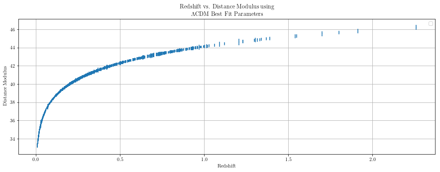

```
No handles with labels found to put in legend.
```

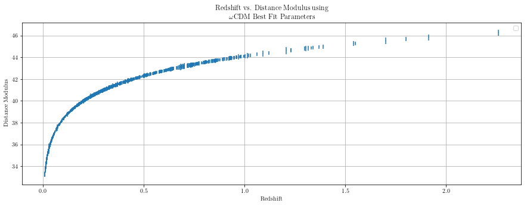

```python
def opt_μ_lambda():
    ## Distance Modulus using best fit parameters for ΛCDM
    z = dataArray(2)
    m = dataArray(4)
    ΩM = opt_lambda_val[1]
    ΩΛ = opt_lambda_val[2]
    w = -1
    dist_mod = μ_model_lambda(ΩM, ΩΛ, z, w )
    return dist_mod

def opt_μ_omega():
    ## Distance Modulus using best fit parameters for ωCDM
    z = dataArray(2)
    m = dataArray(4)
    ΩM = opt_omega_val[1]
    ΩΛ = 1 - ΩM
    w = opt_omega_val[2]
    dist_mod = μ_model_omega(ΩM, ΩΛ, z, w )
    return dist_mod

## Distance Modulus graph for ΛCDM
plt.figure(figsize=(15,5))
plt.title('Redshift vs. Distance Modulus using \n $\Lambda$CDM Best Fit Parameters')
## Plotted error bars represent uncertainty in the apparent magnitude in the data
plt.errorbar(dataArray(2),opt_μ_lambda(),yerr=dataArray(5),xerr= dataArray(3),fmt=',')
#plt.axvline(np.median(dataArray(2)),label='dataset median',c='r')
plt.grid(b=1)
plt.xlabel('Redshift')
plt.ylabel('Distance Modulus')
plt.legend()
plt.savefig('LambdaBestFitDistMod')
plt.show();
plt.clf()

## Distance Modulus graph for ωCDM
plt.figure(figsize=(15,5))
plt.title('Redshift vs. Distance Modulus using \n $\omega$CDM Best Fit Parameters')
## Plotted error bars represent uncertainty in the apparent magnitude in the data
plt.errorbar(dataArray(2),opt_μ_omega(),yerr=dataArray(5),xerr= dataArray(3),fmt=',')
#plt.axvline(np.median(dataArray(2)),label='dataset median',c='r')
plt.grid(b=1)
plt.xlabel('Redshift')
plt.ylabel('Distance Modulus')
plt.legend()
plt.savefig('omegaBestFitDistMod')
plt.show();
plt.clf()
```

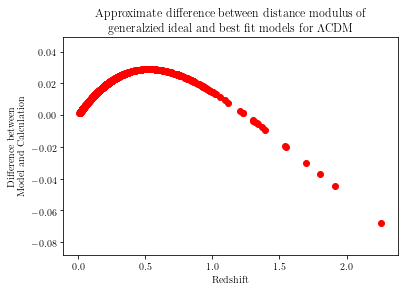

```python
rs = dataArray(2)
model_lambda = μ_model_lambda(0.3, 0.7, rs, -1 )
calculated_lambda = μ_model_lambda(opt_lambda(init_guess_lambda)[1], opt_lambda(init_guess_lambda)[2], rs, -1 )
diff = calculated_lambda - model_lambda
plt.scatter(rs, diff,c='r')
plt.xlabel('Redshift')
plt.ylabel('Difference between \n Model and Calculation')
plt.title('Approximate difference between distance modulus of \n generalzied ideal and best fit models for $\Lambda$CDM')
plt.savefig('approximateDifference')
plt.show()
plt.clf()
```

## Markov Chain Monte Carlo (MCMC) Analysis and Parameter Uncertainty

Since we know the data set itself has a standard error, it follows that there is a degree of error in the best fit we derived. At first glance, the range of plausible values seems very difficult to determine, but fortunately there exists an oppurtunity to find this range in the form of Markov Chain Monte Carlo (MCMC) analysis. To put it simply, MCMC analysis takes a lightly constrained probability function (in our case, we constrain the parameters to ensure they are of the correct sign and don't vastly exceed the amount of matter in the universe) and traces out an area of plausible values for this function.

To do this, one has a set of "walkers" start at a given value for each parameter being evaluated and has them take a very small step in a random direction. With enough steps, the walkers will trace out a range of plausible values for the parameters. In order to avoid a dependence on the starting position of each value, it is suggested to do a "burn-in" run where a smaller number of steps are taken by the walkers before saving their random position at the end of the burn-in run and resetting the algorithm. From there, one uses these randomized intitial conditions to then do a longer testing run, where the walkers will trace out the plausible values. While increasing the number of walkers and the number of steps increases the accuracy of this range of values, MCMC analysis can quickly become extremely computationally expensive, especially in our case, where we do not make use of multithreading. As a result, we have used the highest number of walkers and steps we can have run in a reasonable amount of time.

In order to accomplish this, we make use of the $\texttt{emcee}$ python library, which allows one to conduct MCMC analysis much quicker than creating the model from scratch. In our case, the probability function is characterized by use of the previously explained penalty function alongside a small number of constraints to keep the MCMC analysis from trying to evaluate values of the parameters that would return errors. Each parameter requires its own initial condition for both the burn-in and main run. In this instance, we are analysing the $\Lambda$CDM model, so we plot the values of $\Omega_{M}$ vs. $\Omega_{\Lambda}$ to see the generally plausible values. While this is a useful visualization of the errors of the parameters, it doesn't tell us concretely what the error values are, nor does it plot all of the parameters together. Fortunately, the $\texttt{corner}$ library allows us to do just that, and, using the values for each parameter in the array created by $\texttt{emcee}$, we can see the distribution of the values of each parameter vs each other, a histogram of the values of each parameter, and values for the uncertainty of each parameter.

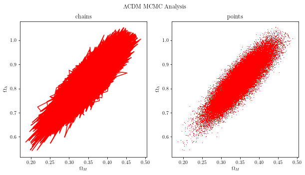

```python
def lnprob_lambda(params):
    ## given the parameters of the ΛCDM model, constrains penalty function to within plausible values by returning the penalty only when
    ## the parameters meet the given conditions
    M = params[0]
    ΩM = params[1]
    ΩΛ = params[2]
    val = [M, ΩM, ΩΛ]
    #print(val)
    if M >= 0:
        return -np.inf
    elif ΩM <= 0 or ΩM >= 0.5:
        return -np.inf
    elif ΩΛ <= 0 or ΩΛ >= 1.5:
        return -np.inf
    elif ΩM + ΩΛ >= 1.5:
        return -np.inf
    else:
        return -0.5*ΛCDM_Χ(val)

ndim = 3 ## number of dimensions (parameters) being evaluated
nwalk = 30 ## number of walkers being run
nburn = 1000 ## number of steps to take in for burn in run
nmain = 5000 ## number of steps to take in main run

p0 = np.zeros((nwalk,ndim))
opt_lambda= opt_lambda(init_guess_lambda)

for i in range(nwalk):
    p0[i,0] = np.random.uniform(low=0, high=1e-10) + opt_lambda[0]
    p0[i,1] = np.random.uniform(low=0, high=1e-10) + opt_lambda[1]
    p0[i,2] = np.random.uniform(low=0, high=1e-10) + opt_lambda[2]

samp = es(nwalk,ndim,lnprob_lambda)

pos,prob,state = samp.run_mcmc(p0,nburn,progress=True)

samp.reset()

res = samp.run_mcmc(pos,nmain,progress=True)
samples_lambda = samp.chain.reshape((-1,ndim))

f,ax = plt.subplots(1,2,figsize=(10,5))
for iwalk in range(nwalk):
    ax[0].plot(samp.chain[iwalk,:,1],samp.chain[iwalk,:,2],'r')
    ax[1].plot(samp.chain[iwalk,:,1],samp.chain[iwalk,:,2],'r,')

ax[0].set_title('chains')
ax[1].set_title('points')
for i in range(0,2):
    ax[i].set_xlabel(r'$\Omega_{M}$')
    ax[i].set_ylabel(r'$\Omega_{\Lambda}$')
f.suptitle(r'$\Lambda$CDM MCMC Analysis')
f.savefig('lambdaMcmcPlot')
```

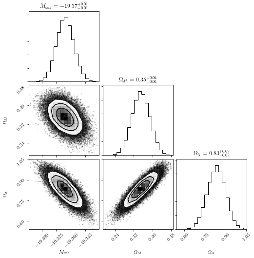

```python
f_lambda = corner.corner(samples_lambda,show_titles=True,labels=(r'$M_{abs}$',r'$\Omega_{M}$',r'$\Omega_{\Lambda}$'))
f_lambda.savefig('LambdaCornerPlot')
```

Here, we do the same MCMC analysis as above using the $\texttt{emcee}$ library, but we are now analyzing the case of the $\omega$CDM model. As a result, in our initial graphing of plausible values, we plot the values of $\Omega_{M}$ against the values of $\omega$. Plotting $\Omega_{M}$ against $\Omega_{\Lambda}$ would not be particularly informative in this case as the value of $\Omega_{\Lambda}$ is entirely dependent on that of $\Omega_{M}$ since we only treat $\Omega_{M}$ as a parameter to evaluate in our penalty function and therefore MCMC analysis. Using $\texttt{corner}$ again gives us the uncertainty of the best fit values of each of the cosmological parameters we constrain in this model.

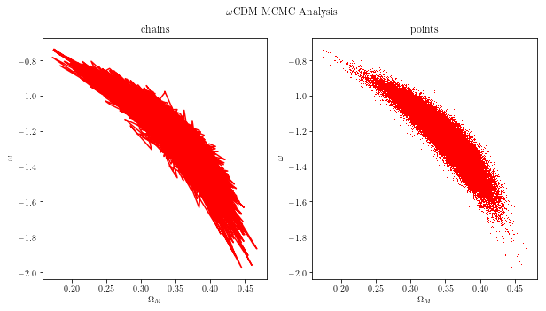

```python
large_plot
def lnprob_omega(params):
    ## given the parameters of the ωCDM model, constrains penalty function to within plausible values by returning the penalty only when
    ## the parameters meet the given conditions
    M = params[0]
    ΩM = params[1]
    ΩΛ = 1 - ΩM
    w = params[2]
    val = [M, ΩM, w]
    #print(val)
    if M >= 0:
        return -np.inf
    elif ΩM <= 0 or ΩM >= 0.5:
        return -np.inf
    elif ΩΛ <= 0 or ΩΛ >= 1.5:
        return -np.inf
    elif ΩM + ΩΛ >= 1.5:
        return -np.inf
    else:
        return -0.5*ωCDM_Χ(val)

ndim = 3 ## number of dimensions (parameters) being evaluated
nwalk = 30 ## number of walkers being run
nburn = 1000 ## number of steps to take in for burn in run
nmain = 5000 ## number of steps to take in main run

p0 = np.zeros((nwalk,ndim))
opt_omega= opt_omega(init_guess_omega)

for i in range(nwalk):
    p0[i,0] = np.random.uniform(low=0, high=1e-10) + opt_omega[0]
    p0[i,1] = np.random.uniform(low=0, high=1e-10) + opt_omega[1]
    p0[i,2] = np.random.uniform(low=0, high=1e-10) + opt_omega[2]

samp = es(nwalk,ndim,lnprob_omega)

pos,prob,state = samp.run_mcmc(p0,nburn,progress=True) ## burn in run

samp.reset()

res = samp.run_mcmc(pos,nmain,progress=True)  ## main run
samples_omega = samp.chain.reshape((-1,ndim))

f,ax = plt.subplots(1,2,figsize=(10,5))
for iwalk in range(nwalk):
    ax[0].plot(samp.chain[iwalk,:,1],samp.chain[iwalk,:,2],'r')
    ax[1].plot(samp.chain[iwalk,:,1],samp.chain[iwalk,:,2],'r,')

ax[0].set_title('chains')
ax[1].set_title('points')
for i in range(0,2):
    ax[i].set_xlabel(r'$\Omega_{M}$')
    ax[i].set_ylabel(r'$\omega$')
f.suptitle(r'$\omega$CDM MCMC Analysis')
f.savefig('omegaMcmcPlot')
```

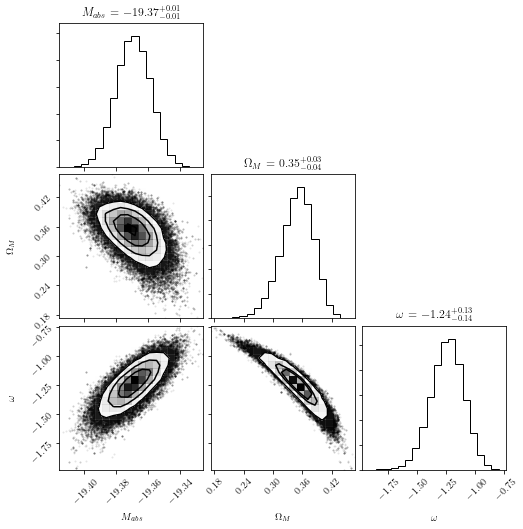

```python
f_omega = corner.corner(samples_omega,show_titles=True,labels=(r'$M_{abs}$',r'$\Omega_{M}$',r'$\omega$'))
f_omega.savefig('omegaCornerPlot')
```